# D3 Project AS2020

#### Task 5

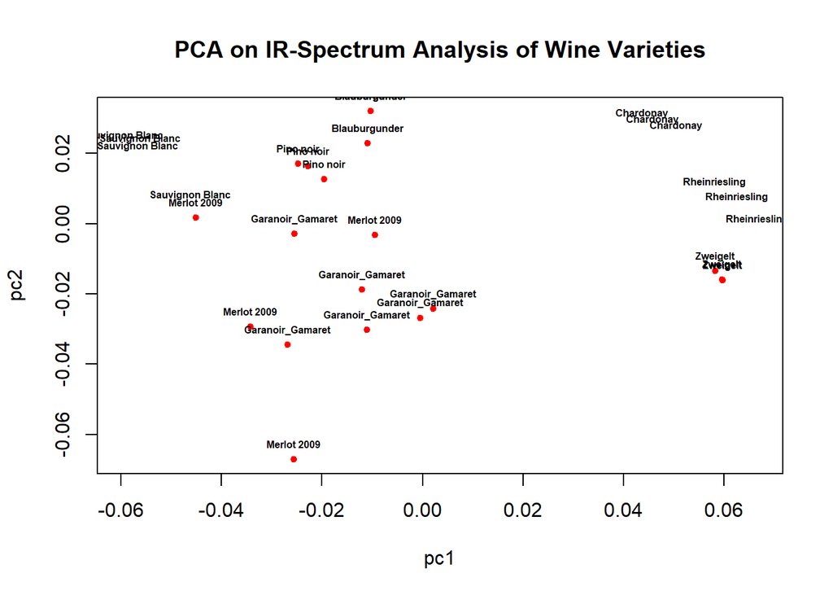

```r
#for comparison reasoning I choose to use PCA too for task 4
data2=my_data[10:n]
my_data_pca=prcomp(data2)
pc=predict(my_data_pca)
pc1=pc[,1]
pc2=pc[,2]

plot(pc1,pc2,
     pch=20,
     cex=1,
     col=my_data$color,#for the 2 classes red and white
     main = paste("PCA on IR-Spectrum Analysis of Wine Varieties")
)
text(pc2~pc1,labels=my_data$name,data=my_data, cex=0.5, font=2, pos=3)
```

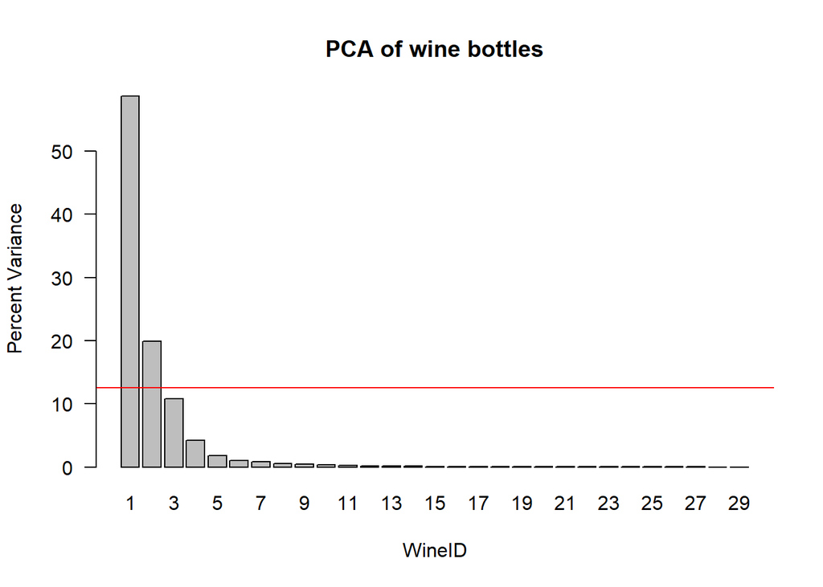

```r
sd=my_data_pca$sdev
variance = sd^2 #variance
var.percent = variance/sum(variance) * 100 #percentage of variance
#plot:
barplot(var.percent , xlab="WineID", ylab=" Percent Variance",names.arg=1:length(var.percent),
        las=1, ylim=c(0,max(var.percent)), col="gray", main=paste("PCA of wine bottles")
)
abline(h=1/ncol(my_data[10:17])*100, col="red") #12 percentage
```

```r
length(which(var.percent>(100*1/nrow(my_data[10:17]))))
```

```
## [1] 4
```

Discussion: A Percent Variance plot is done for Dimension reduction to illustrate the relevant information in two dimension. Firstly, in the x-axis the principial components are shown. Firstly, it calculate the the axis with the greatest variance and than the second pc by calculating the axis with the greatest variance with a coordinate system of 28 components.Doing this for all other components. After that, a line over the plot is fitted and it seems only the first two are above the line. The line is a form of selection criterium for the first eight pc.However, the first component is greater than 50%, whereas the second component is 20%.

#### Task 6

```r
#pc at least 97%
length(which(var.percent>(97*1/nrow(my_data[10:n]))))
```

```
## [1] 4
```

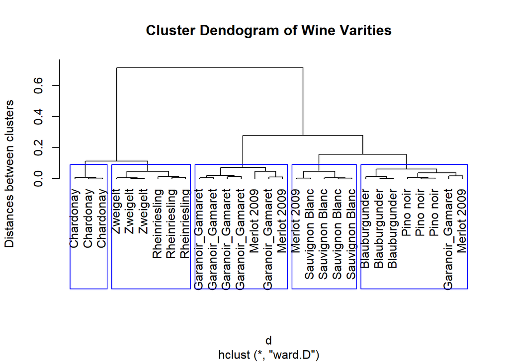

```r
#perform a wards clustering
#label the dendogram using the wine varieties.
#confusion matrix, actual classes
d = dist(MDS) # creates a object with the interpoint distances
hc= hclust(d , method ="ward.D") #the result of hclust is written into hc
democut = cutree ( hc , k =2) #try and find out
democut2 = cutree ( hc , h =0.65)
# new plot :
plot(hc, hang = -1,
     my_data$name,
     main="Cluster Dendogram of Wine Varities",
     ylab = "Distances between clusters")
# draw dendogram with blue borders around the 5 clusters
rect.hclust( hc , k =5 , border ="blue")
```

```r
# confusion matrix
k=8
actual_classes=as.matrix(my_data$name) #actual labels as matrix
predicted_classes = cutree(hc,k) #predicted cluster labels
confusion_matrix = table(actual_classes, predicted_classes)
confusion_matrix
```

```
##                   predicted_classes
## actual_classes     1 2 3 4 5 6 7 8
##   Blauburgunder    3 0 0 0 0 0 0 0
##   Chardonay        0 0 0 0 0 0 3 0
##   Garanoir_Gamaret 0 1 1 4 0 0 0 0
##   Merlot 2009      0 2 1 0 1 0 0 0
##   Pino noir        0 0 3 0 0 0 0 0
##   Rheinriesling    0 0 0 0 0 3 0 0
##   Sauvignon Blanc  0 0 0 0 1 0 0 3
##   Zweigelt         0 0 0 0 0 3 0 0
```

Discussion: In practice, Ward’s method is often considered the most reliable hierarchical clustering method (yielding the most reliable results). In the following plot you can see 5 clusters of the wine varieties using a Cluster Dendogram. Furthermore, you can take the confusion matrix to assess the correctness of the clustering. For example “Blauburgunder” is well predictet with 3 times in the predicted class 1. With execption the “Garanoir_Gamaret, which in confusion matrix as well as in the Dendogramm is not predicted well, it is a misclassification. Additionally, the classes”Merlot 2009" and “Sauvignon Blanc” are not predicted well. Overall, for a definite clustering of the wine varieties it needs to consider the whole wine varieties of the data set “selection_parameters”.